# ADS 503 Project

Hunter Blum, Brianne Bell, Eva Chow

2022-06-21

### Libraries

```r
library(haven)
library(caret)
library(gridExtra)
library(corrplot)
library(e1071)
library(car)
library(lattice)
library(doParallel)
library(RANN)
library(rpart)
library(party)
library(partykit)
library(rpart.plot)
library(randomForest)
library(RWeka)
library(gbm)
library(Cubist)

library(tidyverse)
```

### Set up Parallelization

```r
cl <- makeCluster(6)
registerDoParallel(cl)
```

# Creating Dataset

### Read in data

```r
Demographic <- read_xpt("P_DEMO.XPT")
BodySize <- read_xpt("P_BMX.XPT")
Chol_ldl <- read_xpt("P_TRIGLY.XPT")
```

### Chol-ldl

```r
#Select Variables of interest
Chol_ldl <- Chol_ldl %>% select(SEQN, LBDLDL)
#NA in target feature won't be useful
Chol_ldl <- Chol_ldl %>% drop_na()
```

### Demographic

```r
#Get rid of variables we don't need
Drop_col <- c('SDDSRVYR', 'RIDSTATR', 'RIDEXMON', 'SIAPROXY', 'SIAINTRP', 'FIAPROXY', 'FIAINTRP', 'MIAPROXY', 'MIAINTRP', 'WTINTPRP', 'WTMECPRP', 'SDMVPSU', 'SDMVSTRA')
Demographic <- Demographic %>% select(-one_of(Drop_col))
```

### BodySize

```r
Drop_col <- c('BMIWT', 'BMIRECUM', 'BMIHEAD', 'BMIHT', 'BMILEG', 'BMIARML', 'BMIARMC', 'BMIWAIST', 'BMIHIP', 'BMDSTATS')
BodySize <- BodySize %>% select(-one_of(Drop_col))
```

### Join

```r
J1 <- Chol_ldl %>% left_join(Demographic, by = "SEQN")
Chol <- J1 %>% left_join(BodySize, by = "SEQN")
Chol <- Chol %>% select(!SEQN)
```

# Cleaning

## Changing factors for EDA

### Changing Variables to the Correct Type

```r
Chol_2 <- Chol
factors <- c("RIAGENDR", "RIDRETH1", "RIDRETH3", "DMDBORN4", "DMDEDUC2", "DMDMARTZ", "RIDEXPRG", "SIALANG", "FIALANG", "MIALANG", "AIALANGA")
Chol_2[,factors] <- lapply(Chol_2[,factors], factor)
```

### Change factor levels to be more interpretable

```r
levels(Chol_2$RIAGENDR) <- c("Male", "Female")
levels(Chol_2$RIDRETH1) <- c("Mex", "OHis", "White", "Black", "Oth")
levels(Chol_2$RIDRETH3) <- c("Mex", "OHis", "White", "Black", "Asian", "Oth")
levels(Chol_2$DMDBORN4) <- c("USA", "Oth", "Ref", "DK")
levels(Chol_2$DMDYRUSZ) <- c("<5", "5-15", "15-30", ">30", "Ref", "DK")
levels(Chol_2$DMDEDUC2) <- c("<9", "9-11", "HS", "AA", "BS+", "Ref", "DK")
levels(Chol_2$DMDMARTZ) <- c("Mar", "Sep", "Nev", "Ref", "DK")
levels(Chol_2$RIDEXPRG) <- c("Yes", "No", "DK")
levels(Chol_2$SIALANG) <- c("English", "Spanish")
levels(Chol_2$FIALANG) <- c("English", "Spanish")
levels(Chol_2$MIALANG) <- c("English", "Spanish")
levels(Chol_2$AIALANGA) <- c("English", "Spanish", "Asian")
```

# EDA

## NAs

### By Variable - Removed variables with over 3000 observations missing

```r
Variable_na <- Chol_2 %>% select(everything()) %>% summarise_all(funs(sum(is.na(.)))) %>% pivot_longer(cols = c(colnames(Chol_2[,1:ncol(Chol_2)])), names_to = "Variable", values_to = "Missing") %>% arrange(desc(Missing))
Drop_col <- c("RIDAGEMN", "BMXRECUM", "BMXHEAD", "BMDBMIC", "RIDEXPRG", "DMDYRUSZ")
Chol_2 <- Chol_2 %>% select(-one_of(Drop_col))
```

### By Row

```r
row_na <- rowSums(is.na(Chol_2))
row_na <- data.frame(row_na, Row = c(1:length(row_na)))
row_na <- row_na %>% arrange(desc(row_na))
#Most missing values in a row is 12, not bad
```

## Distributions

### Response - LDL Cholesterol

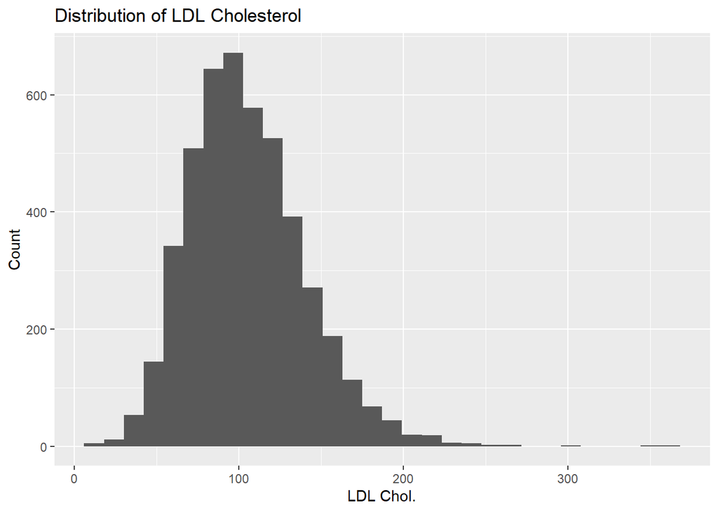

```r
#Looks like a fairly normal distribution, maybe a little skewed to the right.
ggplot(Chol_2, aes(x = LBDLDL)) + geom_histogram() + ggtitle("Distribution of LDL Cholesterol") + xlab("LDL Chol.") + ylab("Count")
```

```r
skewness(Chol_2$LBDLDL)
```

```
## [1] 0.7886403
```

```r
#skewness value .7886403 confirms very mild skewness to the right
```

### Predictors

Factors

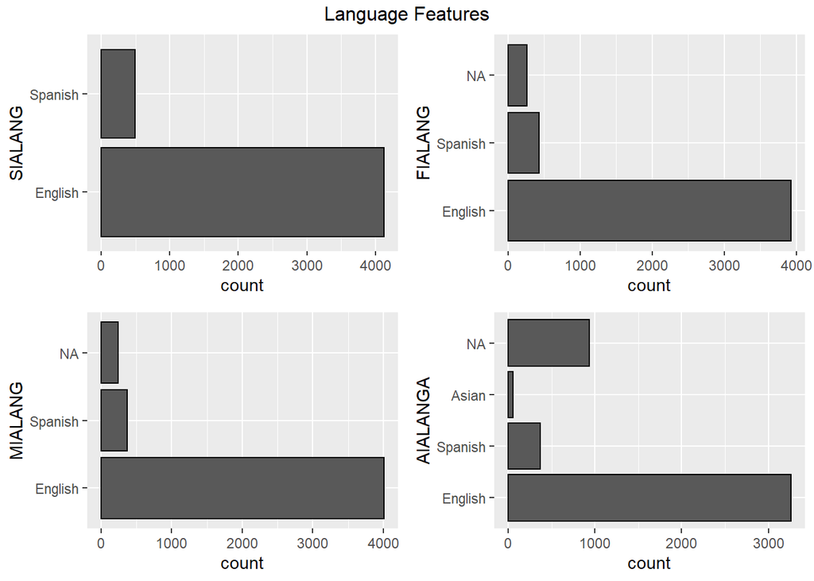

```r
Chol_fact <- Chol_2 %>% select_if(is.factor)
Chol.bar <- function(xvar){
  ggplot(Chol_fact, aes_(x = as.name(xvar))) +
    geom_bar(color = "black") + coord_flip()
}
Lang_barplots <- lapply(names(Chol_fact[,7:10]), Chol.bar)
Oth_barplots <- lapply(names(Chol_fact[,1:6]), Chol.bar)
grid.arrange(grobs = Lang_barplots, top = "Language Features")
```

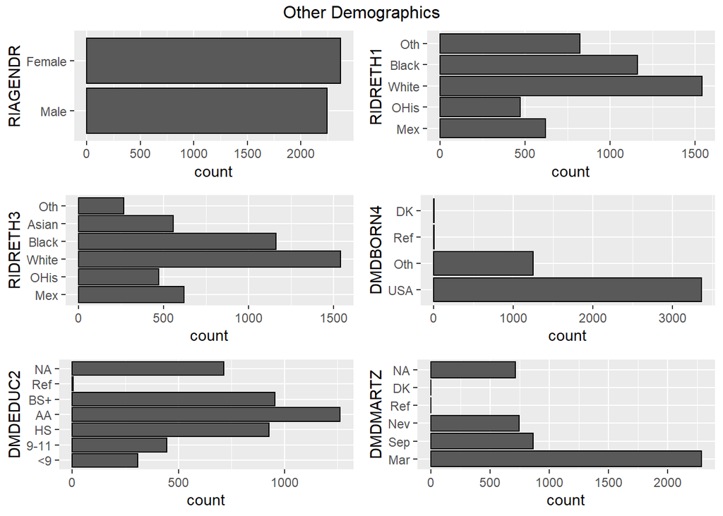

```r
grid.arrange(grobs = Oth_barplots, top = "Other Demographics")
```

Numeric

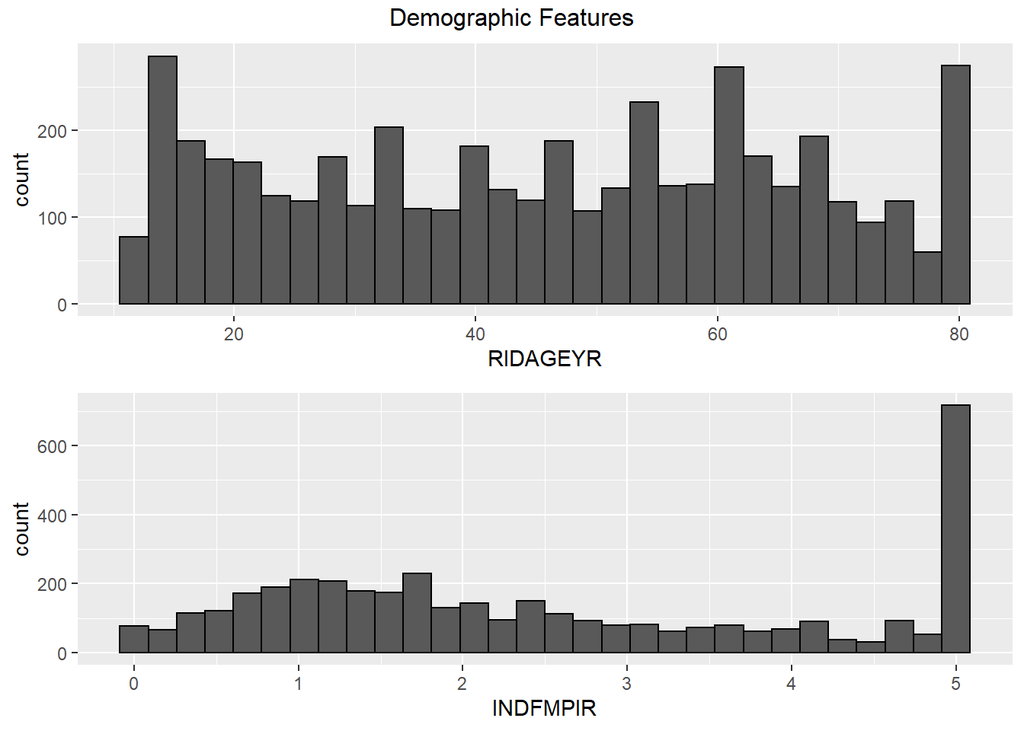

```r
Chol_num <- Chol_2 %>% select_if(is.numeric) %>% select(!LBDLDL)
Chol.hist <- function(xvar){
  ggplot(Chol_num, aes_(x = as.name(xvar))) +
    geom_histogram(color = "black")
}
Dem_hist <- lapply(names(Chol_num[,1:2]), Chol.hist)
Body_hist <- lapply(names(Chol_num[,3:10]), Chol.hist)
grid.arrange(grobs = Dem_hist, top = "Demographic Features")
```

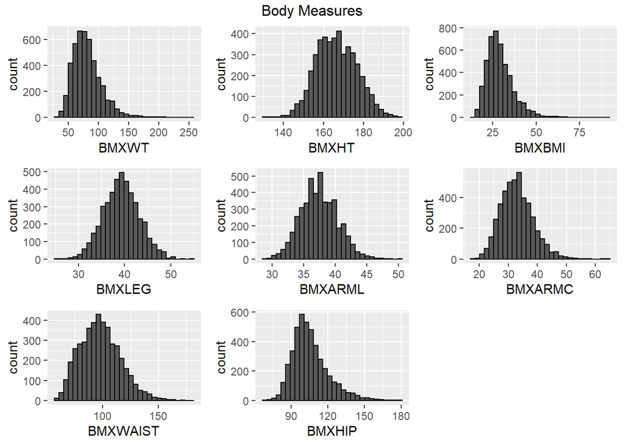

```r
grid.arrange(grobs = Body_hist, top = "Body Measures")
```

## Correlations

Heatmap

```r
Chol_dummy <- fastDummies::dummy_cols(Chol_2)
Chol_dummy <- Chol_dummy %>% select_if(~!is.factor(.))
Chol_dummy[] <- lapply(Chol_dummy, as.numeric)
Chol_cor <- cor(Chol_dummy, use = "complete.obs")
```

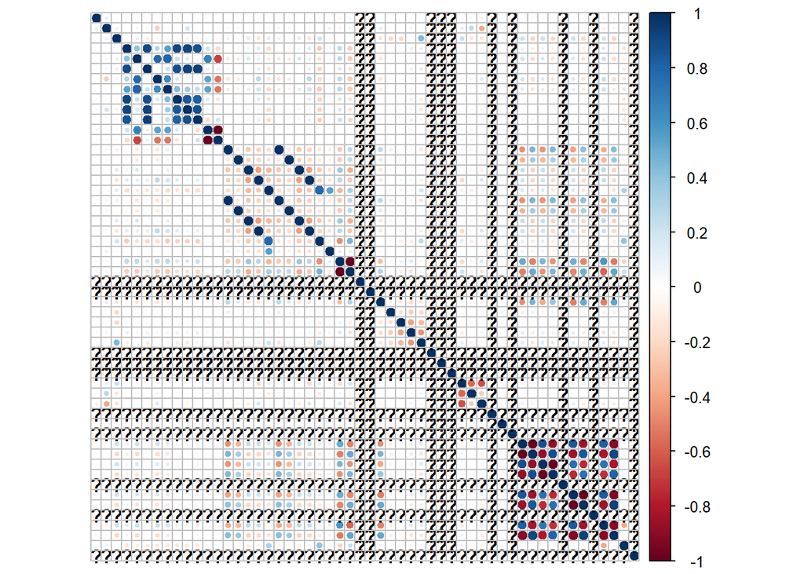

```r
Chol_corplot <- corrplot(cor(Chol_dummy, use = "complete.obs"), tl.pos = 'n')
```

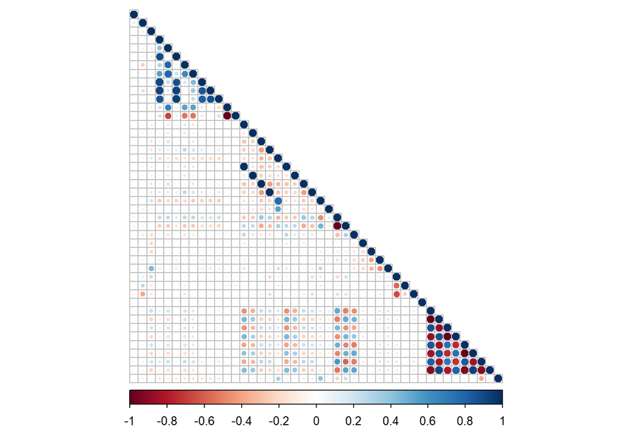

```r
#Looks like some dummy variables that are refusal could be messing up correlations
Drop_col <- c("DMDBORN4_Ref", "DMDBORN4_DK", "DMDEDUC2_Ref", "DMDEDUC2_DK", "DMDEDUC2_NA", "DMDMARTZ_Ref", "DMDMARTZ_NA", "FIALANG_NA", "MIALANG_NA", "AIALANGA_NA")
Chol_dummy_2 <- Chol_dummy %>% select(-one_of(Drop_col))
invisible(cor(Chol_dummy_2, use = "complete.obs")) # using invisible() to reduce extensive output
corrplot(cor(Chol_dummy_2, use = "complete.obs"), tl.pos = 'n', type = 'lower')
```

### Smaller plots for easier interpretation.

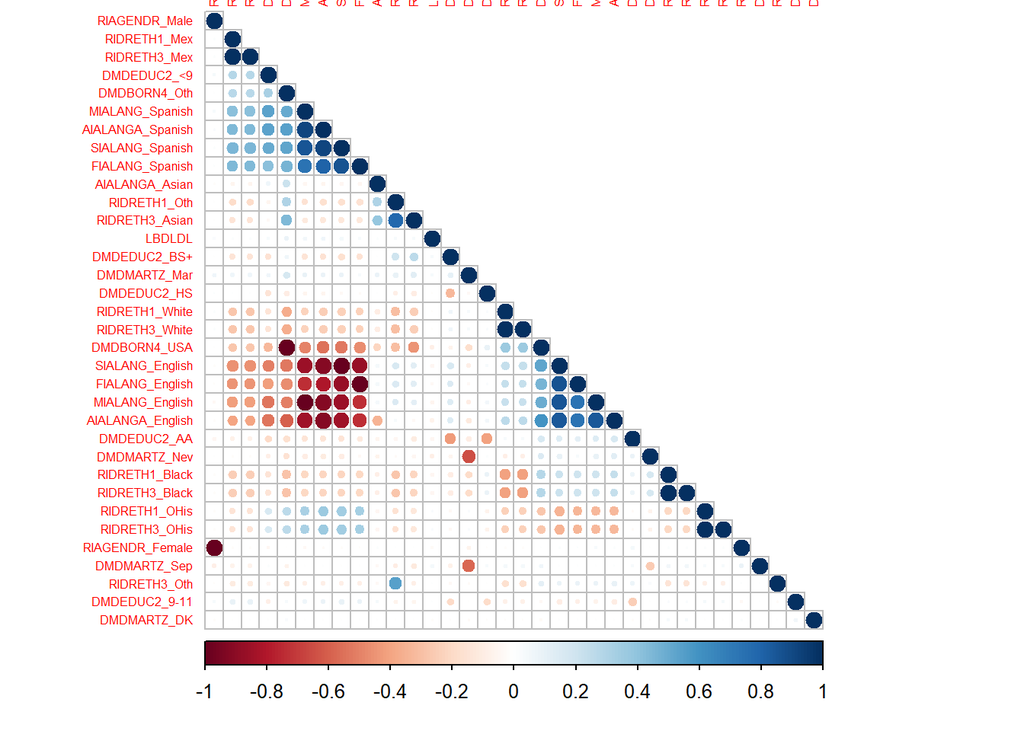

```r
# Mini Correlations: Sociological Measures:
socio <- Chol_dummy_2[,c("RIAGENDR_Male","RIAGENDR_Female",
                       "RIDRETH1_Mex", "RIDRETH1_OHis", "RIDRETH1_White",
                       "RIDRETH1_Black", "RIDRETH1_Oth", "RIDRETH3_Mex", "RIDRETH3_OHis",
                       "RIDRETH3_White", "RIDRETH3_Black", "RIDRETH3_Asian", "RIDRETH3_Oth",
                       "DMDBORN4_USA", "DMDBORN4_Oth", "DMDEDUC2_<9", "DMDEDUC2_9-11",
                       "DMDEDUC2_HS", "DMDEDUC2_AA", "DMDEDUC2_BS+","DMDMARTZ_Mar",
                       "DMDMARTZ_Sep", "DMDMARTZ_Nev", "DMDMARTZ_DK", "SIALANG_English",
                       "SIALANG_Spanish", "FIALANG_English", "FIALANG_Spanish",
                       "MIALANG_English","MIALANG_Spanish", "AIALANGA_English",
                       "AIALANGA_Spanish", "AIALANGA_Asian", "LBDLDL")]

invisible(cor(socio, use = "complete.obs")) # using invisible() to reduce extensive output
corrplot(cor(socio, use = "complete.obs"), tl.pos = 'y', type = 'lower',
         order = "hclust", tl.cex = 0.5)
```

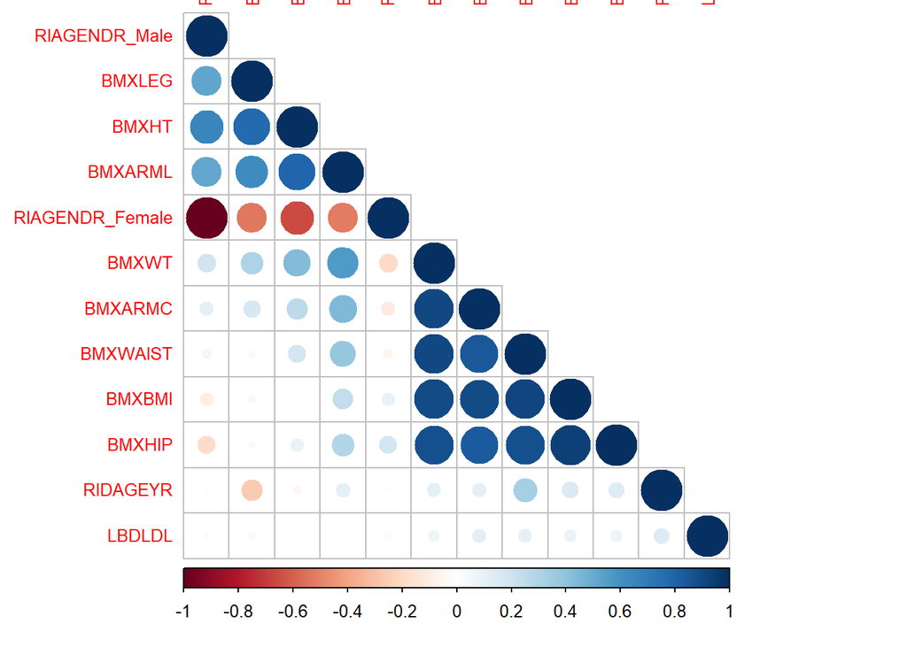

```r
# Mini Correlations: Biological Measures:
biologic <- Chol_dummy_2[,c("RIDAGEYR", "BMXWT", "BMXHT", "BMXBMI",
                            "BMXLEG", "BMXARML", "BMXARMC", "BMXWAIST",
                            "BMXHIP", "RIAGENDR_Male", "RIAGENDR_Female","LBDLDL")]
invisible(cor(biologic, use = "complete.obs")) # using invisible() to reduce extensive output
corrplot(cor(biologic, use = "complete.obs"), tl.pos = 'y', type = 'lower',
         order = "hclust", tl.cex = 0.8)
```

```r
# correlations between certain biological measures make sense. BMI is derived from the MASS and height of an individual, so it makes sense that many of the BMI measurements correlate with each other. (i.e. hip, waist, and weight measurements correlate with a higher BMI. Being female correlates negatively with leg and arm length as well as height)
```

### Highly-correlated variables in cholesterol

Note: Highly correlated variables were removed in the model training process - this was just for EDA

```r
# let's check for highly correlated predictors
# we'll do this on our non factor transformed dataset
dim(Chol)
```

```
## [1] 4617   27
```

```r
# 27 variables. let's find correlations greater than 0.80 and see how the data looks if removed
corr_Chol <- cor(Chol)

# if removed, how many variables are left
high_corr_Chol <- findCorrelation(corr_Chol, cutoff = 0.80)
no_corr_Chol <- Chol[, -high_corr_Chol]
dim(no_corr_Chol)
```

```
## [1] 4617   26
```

### Looking at a simple ols model to get an idea of important predictors.

```r
# looking at a base linear model, to see significant variables
model0 <- lm(LBDLDL~., Chol_2)
summary(model0)
```

```
##
## Call:
## lm(formula = LBDLDL ~ ., data = Chol_2)
##
## Residuals:
##      Min       1Q   Median       3Q      Max
## -102.103  -23.607   -2.937   19.941  248.656
##
## Coefficients: (4 not defined because of singularities)
##                  Estimate Std. Error t value Pr(>|t|)
## (Intercept)     112.86475   55.86920   2.020 0.043473 *
## RIAGENDRFemale   -1.91563    2.57466  -0.744 0.456926
## RIDAGEYR          0.24155    0.06308   3.829 0.000132 ***
## RIDRETH1OHis      0.32070    2.94340   0.109 0.913247
## RIDRETH1White     2.35185    2.76857   0.849 0.395694
## RIDRETH1Black    -0.73860    2.94082  -0.251 0.801716
## RIDRETH1Oth       4.71480    3.77829   1.248 0.212196
## RIDRETH3OHis           NA         NA      NA       NA
## RIDRETH3White          NA         NA      NA       NA
## RIDRETH3Black          NA         NA      NA       NA
## RIDRETH3Asian    -2.84491    4.23201  -0.672 0.501495
## RIDRETH3Oth            NA         NA      NA       NA
## DMDBORN4Oth       4.36638    2.46324   1.773 0.076414 .
## DMDEDUC29-11      4.10693    3.99431   1.028 0.303959
## DMDEDUC2HS        2.20049    3.78025   0.582 0.560550
## DMDEDUC2AA        1.20340    3.78500   0.318 0.750558
## DMDEDUC2BS+       3.46252    3.97469   0.871 0.383761
## DMDMARTZSep       1.97727    1.98256   0.997 0.318702
## DMDMARTZNev      -1.53988    1.94945  -0.790 0.429657
## DMDMARTZDK      -41.40880   35.15436  -1.178 0.238943
## SIALANGSpanish   -7.99794    6.62103  -1.208 0.227177
## FIALANGSpanish    0.40544    4.87296   0.083 0.933697
## MIALANGSpanish   -5.35299    6.25014  -0.856 0.391825
## AIALANGASpanish  15.53960    7.63044   2.037 0.041803 *
## AIALANGAAsian     1.27914    5.50446   0.232 0.816261
## INDFMPIR          0.52626    0.52568   1.001 0.316879
## BMXWT            -0.01949    0.30794  -0.063 0.949549
## BMXHT            -0.38550    0.36123  -1.067 0.286000
## BMXBMI           -0.88512    0.96788  -0.914 0.360544
## BMXLEG            0.69926    0.32788   2.133 0.033051 *
## BMXARML          -0.24752    0.46888  -0.528 0.597616
## BMXARMC           0.98602    0.34684   2.843 0.004507 **
## BMXWAIST          0.24437    0.13572   1.801 0.071888 .
## BMXHIP           -0.01965    0.18110  -0.109 0.913595
## ---
## Signif. codes:  0 '***' 0.001 '**' 0.01 '*' 0.05 '.' 0.1 ' ' 1
##
## Residual standard error: 34.91 on 2498 degrees of freedom
##   (2089 observations deleted due to missingness)
## Multiple R-squared:  0.03362,    Adjusted R-squared:  0.0224
## F-statistic: 2.997 on 29 and 2498 DF,  p-value: 1.543e-07
```

```r
  # significant contributors: variable (Pr(>|t|))
    # RIDAGEYR (0.000132)
    # (Intercept) (0.043474)
    # MDBORN4Oth (0.076414)
    # AIALANGASpanish (0.041803)
    # BMXLEG (0.033051)
    # BMXARMC (0.004507)
    # BMXWAIST (0.071888)
```

Looking at VIF of simple model showed aliased coefficients. Removed them in the model training process.

```r
# looking at VIF for baseline linear:
#vif(model0)
# highly/perfectly correlated factors, we might need to drop some
```

### Degenerate Predictors in the non-dummy dataset

```r
# Let's check for degenerate predictors from the original dataset
nearZeroVar(Chol, saveMetrics = FALSE)
```

```
## [1]  4 11 16 18 19
```

```r
deg_chol <- subset(Chol, select=c(4,11,16,18,19))
colnames(deg_chol)
```

```
## [1] "RIDAGEMN" "RIDEXPRG" "INDFMPIR" "BMXRECUM" "BMXHEAD"
```

```r
# Do it again on factor dataset
nearZeroVar(Chol_2, saveMetrics = FALSE)
```

```
## [1] 13
```

```r
deg_chol2 <- subset(Chol_2, select=c(13))
colnames(deg_chol2)
```

```
## [1] "INDFMPIR"
```

```r
# we may have to consider removing depending on the data used for modeling
```

# Preparing data for modeling

### Splitting dummy-variable data set and resampling

```r
# set the seed and split the data. We'll do an 80/20 split
set.seed(123)
Chol_split <- createDataPartition(Chol$LBDLDL, p=0.80, list=FALSE)

# split into train and test
Chol_train <- Chol_dummy[Chol_split,]
Chol_test <- Chol_dummy[-Chol_split,]

# split predictors from the target
Chol_train_X <- as.data.frame(subset(Chol_train, select=-c(LBDLDL)))
Chol_train_y <- Chol_train$LBDLDL

Chol_test_X <- as.data.frame(subset(Chol_test, select=-c(LBDLDL)))
Chol_test_y <- Chol_test$LBDLDL

# Creating imputed data sets
Chol_imp <- preProcess(Chol_train_X, method = c("center", "scale", "knnImpute"))
Chol_train_X_imp <- predict(Chol_imp, Chol_train_X)
Chol_test_X_imp <- predict(Chol_imp, Chol_test_X)

# Adding Resampling/Validation Set and Control
set.seed(123)
Chol_folds <- createFolds(y = Chol_train_X, k = 10, returnTrain = T)
Chol_control <- trainControl(method = "cv", index = Chol_folds)
```

### Numeric training data set with just the numeric variables and gender (Just going off a hunch that having too many dummy variables is hurting linear model performance).

```r
Drop_col <- c('RIDRETH1', 'RIDRETH3', 'DMDBORN4', 'DMDEDUC2', 'DMDMARTZ', 'SIALANG', 'FIALANG', 'MIALANG', 'AIALANGA', 'LBDLDL')
Chol_num <- Chol_2 %>% select(-one_of(Drop_col))
Chol_dummy <- fastDummies::dummy_cols(Chol_num)
Chol_num <- Chol_dummy %>% select_if(~!is.factor(.))
Chol_num[] <- lapply(Chol_num, as.numeric)

Chol_num_tr_X <- as.data.frame(Chol_num[Chol_split, ])
Chol_num_test_X <- as.data.frame(Chol_num[-Chol_split, ])

#Preprocess
Chol_imp <- preProcess(Chol_num_tr_X, method = c("center", "scale", "knnImpute"))
Chol_num_tr_X <- predict(Chol_imp, Chol_num_tr_X)
Chol_num_test_X <- predict(Chol_imp, Chol_num_test_X)

# Adding Resampling/Validation Set and Control
set.seed(123)
Chol_folds_num <- createFolds(y = Chol_num_tr_X, k = 10, returnTrain = T)
Chol_control_num <- trainControl(method = "cv", index = Chol_folds_num)
```

# Linear Models - Hunter

## OLS

### Create Initial Model

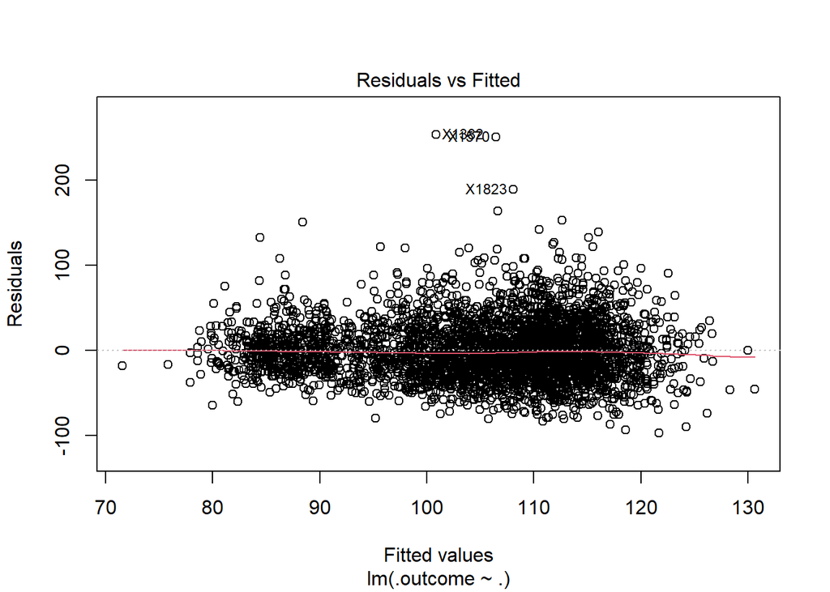

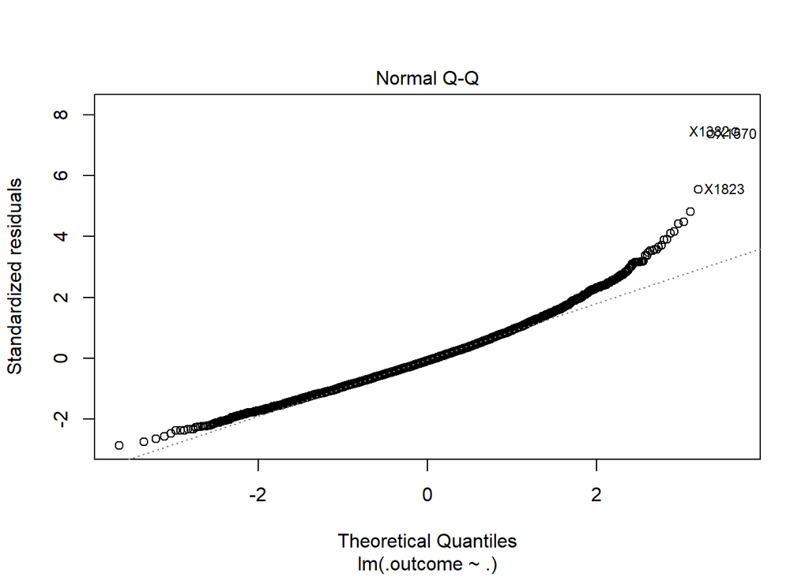

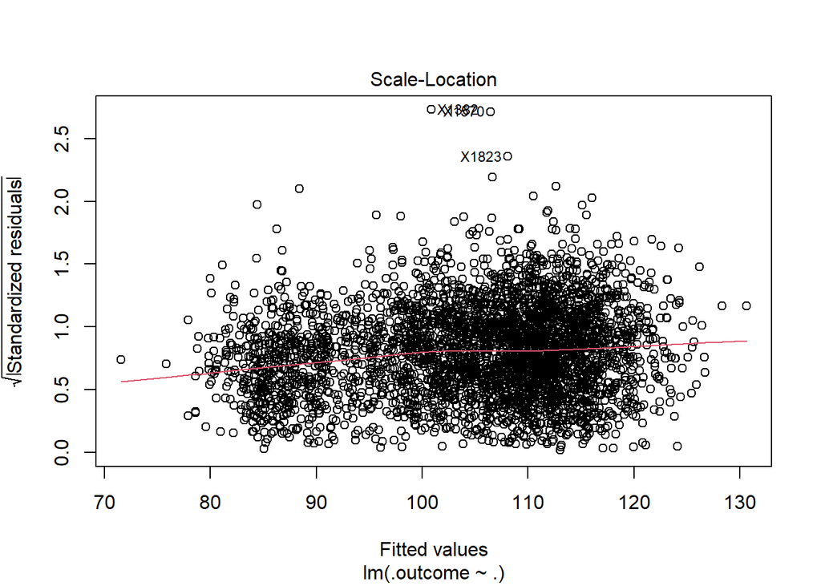

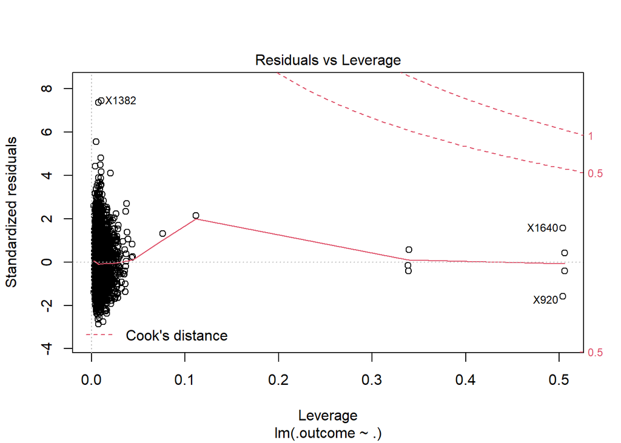

```r
Chol_ols_tune <- train(x = Chol_train_X_imp, y = Chol_train_y, method = "lm", trControl = Chol_control)
plot(Chol_ols_tune$finalModel)
```

### FIX TRAINING SET

```r
# VIF shows aliased coefficients, need to get rid of those by removing high cor predictors
test <- cor(Chol_train_X_imp)
# Also have an issue with DMDEDUC2_DK all being zero so get rid of high var predictors
Chol_tr_x_imp_vr <- Chol_train_X_imp[, -nearZeroVar(Chol_train_X_imp)]
Chol_tr_X_imp_fin <- Chol_tr_x_imp_vr[, -findCorrelation(cor(Chol_tr_x_imp_vr), cutoff = 0.9)]
```

### Tune Another Model

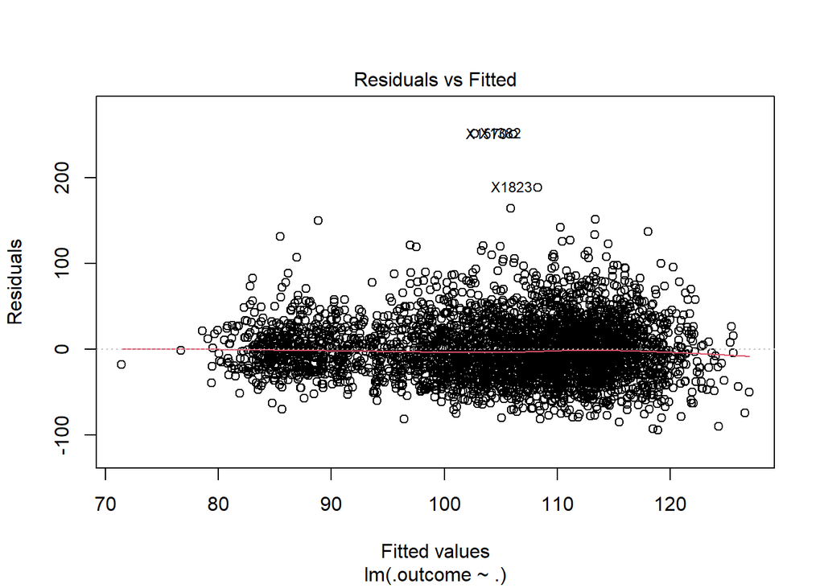

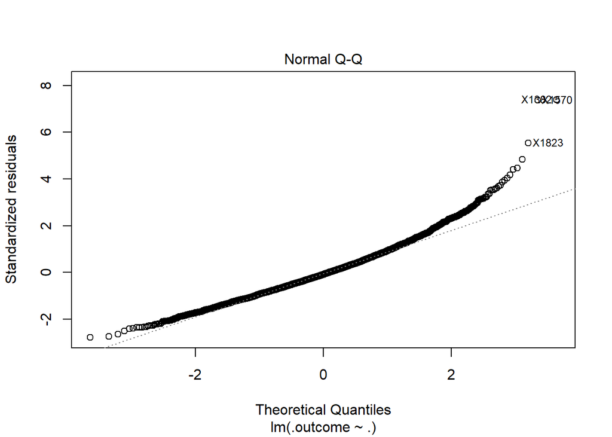

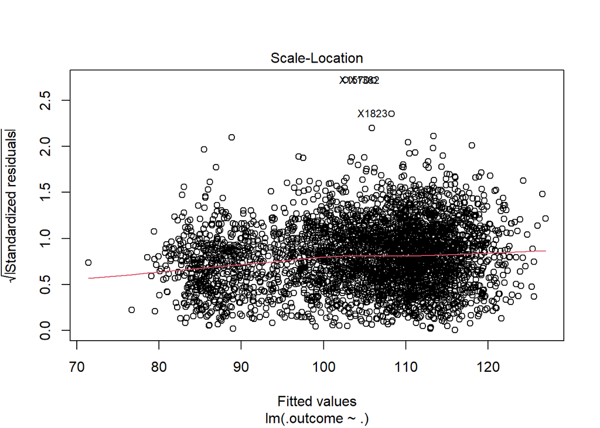

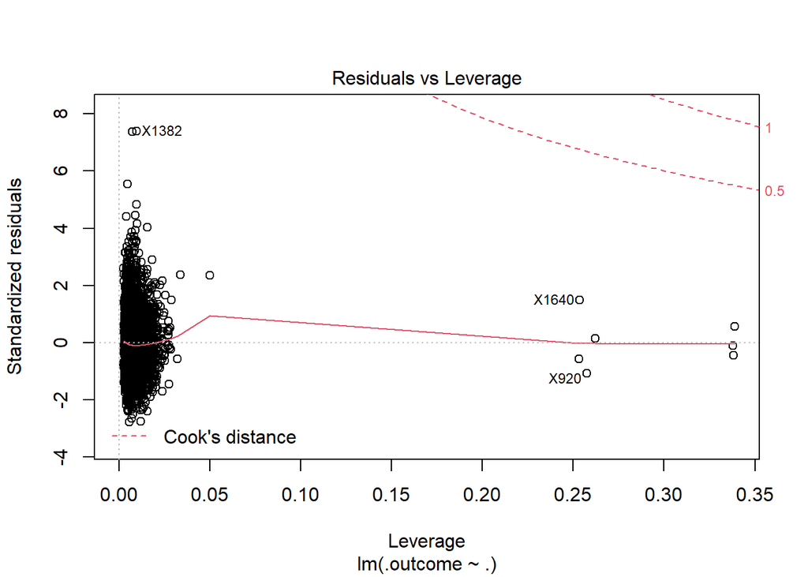

```r
Chol_ols_tune2 <- train(x = Chol_tr_X_imp_fin, y = Chol_train_y, method = "lm", trControl = Chol_control)
plot(Chol_ols_tune2$finalModel)
```

```r
summary(Chol_ols_tune2$finalModel)
```

```
##
## Call:
## lm(formula = .outcome ~ ., data = dat)
##
## Residuals:
##     Min      1Q  Median      3Q     Max
## -94.895 -23.065  -3.065  19.439 251.335
##
## Coefficients: (2 not defined because of singularities)
##                   Estimate Std. Error t value Pr(>|t|)
## (Intercept)      105.31270    0.57066 184.546  < 2e-16 ***
## RIDAGEYR           4.52387    1.05609   4.284 1.89e-05 ***
## INDFMPIR           0.25641    0.71302   0.360  0.71915
## BMXHT             -3.83360    1.33252  -2.877  0.00404 **
## BMXBMI            -4.35512    1.45346  -2.996  0.00275 **
## BMXLEG             2.97807    1.01656   2.930  0.00342 **
## BMXARML            0.27463    1.09490   0.251  0.80196
## BMXARMC            5.96990    1.52805   3.907 9.52e-05 ***
## RIAGENDR_Male     -0.86654    0.80467  -1.077  0.28160
## RIDRETH1_OHis      0.31552    0.75090   0.420  0.67437
## RIDRETH1_Oth       1.30082    1.01537   1.281  0.20023
## RIDRETH3_Mex       1.02780    0.79135   1.299  0.19410
## RIDRETH3_White     0.89147    0.75600   1.179  0.23840
## RIDRETH3_Black          NA         NA      NA       NA
## RIDRETH3_Asian    -0.42976    1.10977  -0.387  0.69859
## RIDRETH3_Oth            NA         NA      NA       NA
## DMDBORN4_Oth       1.91695    0.92813   2.065  0.03896 *
## `DMDEDUC2_<9`     -6.24744    5.32698  -1.173  0.24096
## `DMDEDUC2_9-11`   -5.93924    6.31711  -0.940  0.34719
## DMDEDUC2_HS       -8.35928    8.53591  -0.979  0.32749
## DMDEDUC2_AA       -9.09136    9.35132  -0.972  0.33101
## `DMDEDUC2_BS+`    -7.28858    8.56310  -0.851  0.39474
## DMDEDUC2_NA       -5.14541    0.80362  -6.403 1.72e-10 ***
## DMDMARTZ_Mar       4.16243    8.48632   0.490  0.62382
## DMDMARTZ_Sep       4.08979    7.16973   0.570  0.56842
## DMDMARTZ_Nev       2.60283    6.84793   0.380  0.70390
## SIALANG_Spanish   -0.59672    1.37337  -0.434  0.66395
## FIALANG_Spanish    0.39180    1.11501   0.351  0.72532
## FIALANG_NA        -0.24256    0.56982  -0.426  0.67037
## MIALANG_Spanish   -0.08927    1.15483  -0.077  0.93838
## MIALANG_NA         2.96009    0.68244   4.338 1.48e-05 ***
## AIALANGA_English  -1.19479    1.19890  -0.997  0.31904
## AIALANGA_NA       -6.21091    0.82160  -7.560 5.08e-14 ***
## ---
## Signif. codes:  0 '***' 0.001 '**' 0.01 '*' 0.05 '.' 0.1 ' ' 1
##
## Residual standard error: 34.15 on 3665 degrees of freedom
## Multiple R-squared:  0.08048,    Adjusted R-squared:  0.07296
## F-statistic: 10.69 on 30 and 3665 DF,  p-value: < 2.2e-16
```

### Tune model with BoxCox to see if it will help normality issues - Didn’t do much, we’ll just stick with the non-transformed data. Also tried transformin LDL, didn’t work either.

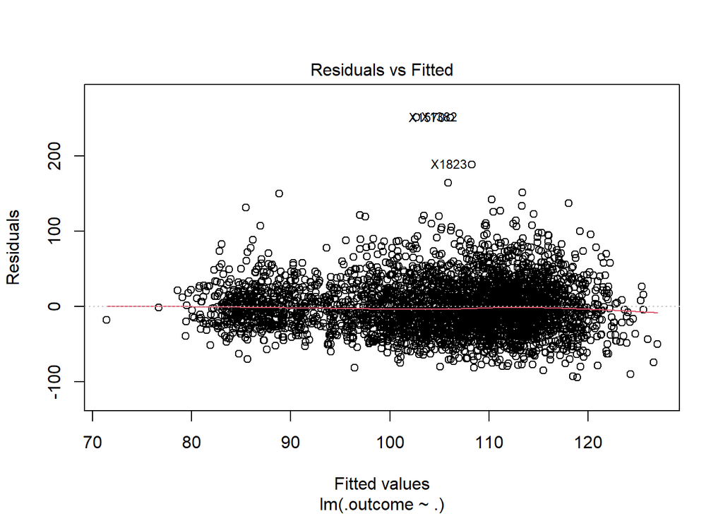

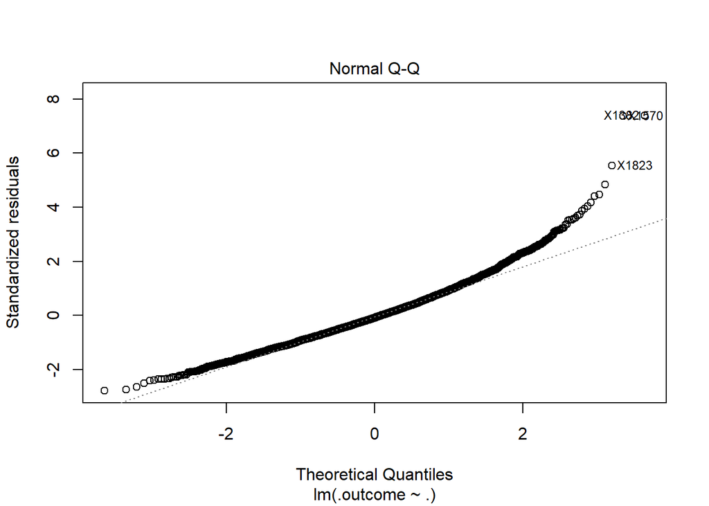

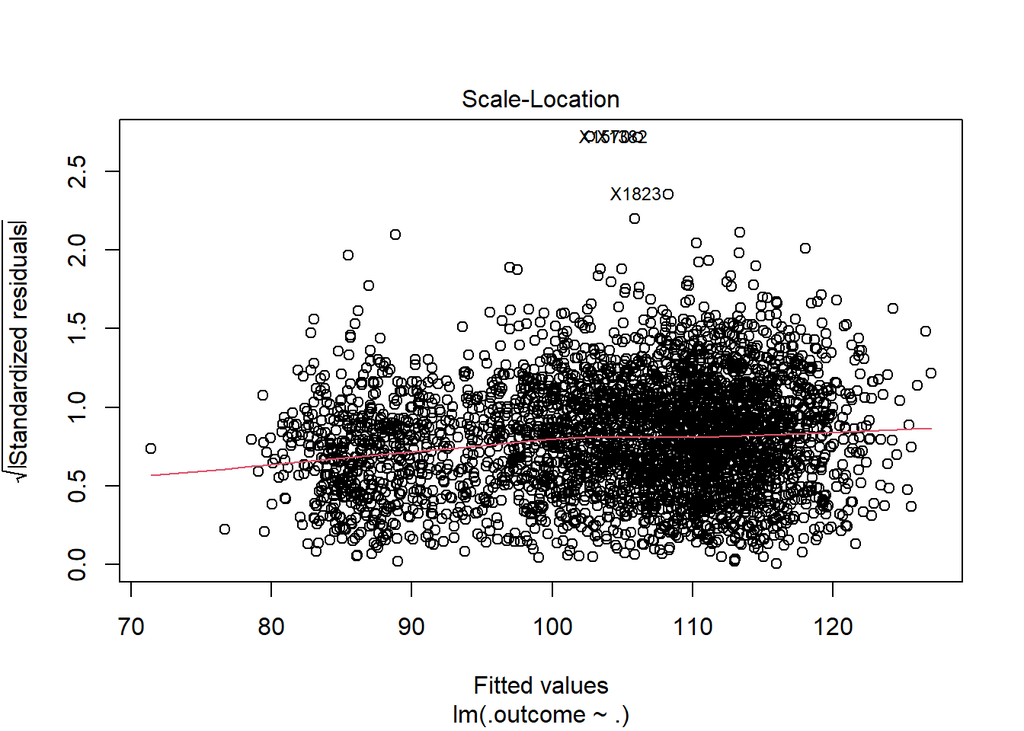

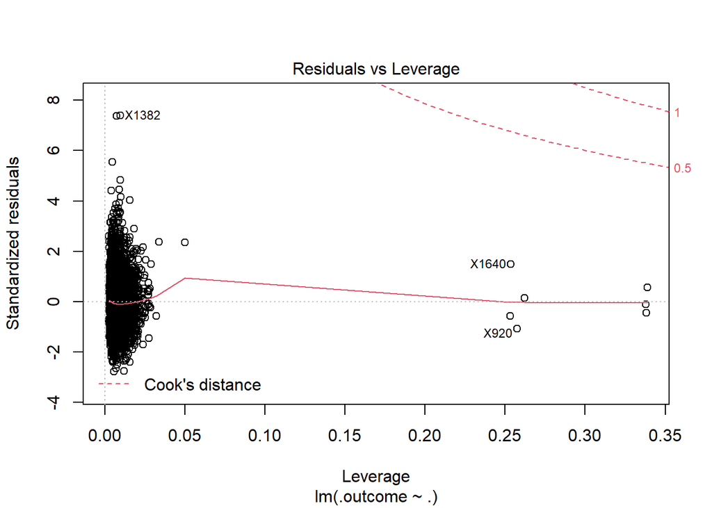

```r
Chol_bct <- preProcess(Chol_tr_X_imp_fin, method = "BoxCox")
Chol_tr_boxcox <- predict(Chol_bct, Chol_tr_X_imp_fin)

Chol_ols_tune3 <- train(x = Chol_tr_boxcox, y = Chol_train_y, method = "lm", trControl = Chol_control)
plot(Chol_ols_tune3$finalModel)
```

```r
summary(Chol_ols_tune3$finalModel)
```

```
##
## Call:
## lm(formula = .outcome ~ ., data = dat)
##
## Residuals:
##     Min      1Q  Median      3Q     Max
## -94.895 -23.065  -3.065  19.439 251.335
##
## Coefficients: (2 not defined because of singularities)
##                   Estimate Std. Error t value Pr(>|t|)
## (Intercept)      105.31270    0.57066 184.546  < 2e-16 ***
## RIDAGEYR           4.52387    1.05609   4.284 1.89e-05 ***
## INDFMPIR           0.25641    0.71302   0.360  0.71915
## BMXHT             -3.83360    1.33252  -2.877  0.00404 **
## BMXBMI            -4.35512    1.45346  -2.996  0.00275 **
## BMXLEG             2.97807    1.01656   2.930  0.00342 **
## BMXARML            0.27463    1.09490   0.251  0.80196
## BMXARMC            5.96990    1.52805   3.907 9.52e-05 ***
## RIAGENDR_Male     -0.86654    0.80467  -1.077  0.28160
## RIDRETH1_OHis      0.31552    0.75090   0.420  0.67437
## RIDRETH1_Oth       1.30082    1.01537   1.281  0.20023
## RIDRETH3_Mex       1.02780    0.79135   1.299  0.19410
## RIDRETH3_White     0.89147    0.75600   1.179  0.23840
## RIDRETH3_Black          NA         NA      NA       NA
## RIDRETH3_Asian    -0.42976    1.10977  -0.387  0.69859
## RIDRETH3_Oth            NA         NA      NA       NA
## DMDBORN4_Oth       1.91695    0.92813   2.065  0.03896 *
## `DMDEDUC2_<9`     -6.24744    5.32698  -1.173  0.24096
## `DMDEDUC2_9-11`   -5.93924    6.31711  -0.940  0.34719
## DMDEDUC2_HS       -8.35928    8.53591  -0.979  0.32749
## DMDEDUC2_AA       -9.09136    9.35132  -0.972  0.33101
## `DMDEDUC2_BS+`    -7.28858    8.56310  -0.851  0.39474
## DMDEDUC2_NA       -5.14541    0.80362  -6.403 1.72e-10 ***
## DMDMARTZ_Mar       4.16243    8.48632   0.490  0.62382
## DMDMARTZ_Sep       4.08979    7.16973   0.570  0.56842
## DMDMARTZ_Nev       2.60283    6.84793   0.380  0.70390
## SIALANG_Spanish   -0.59672    1.37337  -0.434  0.66395
## FIALANG_Spanish    0.39180    1.11501   0.351  0.72532
## FIALANG_NA        -0.24256    0.56982  -0.426  0.67037
## MIALANG_Spanish   -0.08927    1.15483  -0.077  0.93838
## MIALANG_NA         2.96009    0.68244   4.338 1.48e-05 ***
## AIALANGA_English  -1.19479    1.19890  -0.997  0.31904
## AIALANGA_NA       -6.21091    0.82160  -7.560 5.08e-14 ***
## ---
## Signif. codes:  0 '***' 0.001 '**' 0.01 '*' 0.05 '.' 0.1 ' ' 1
##
## Residual standard error: 34.15 on 3665 degrees of freedom
## Multiple R-squared:  0.08048,    Adjusted R-squared:  0.07296
## F-statistic: 10.69 on 30 and 3665 DF,  p-value: < 2.2e-16
```

### Try reduced data - Didn’t really help our diagnostic plot, so we’ll go with the regular dummy data

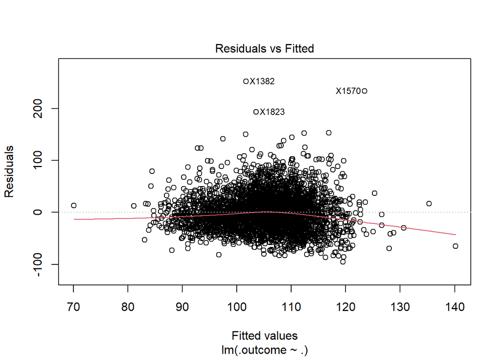

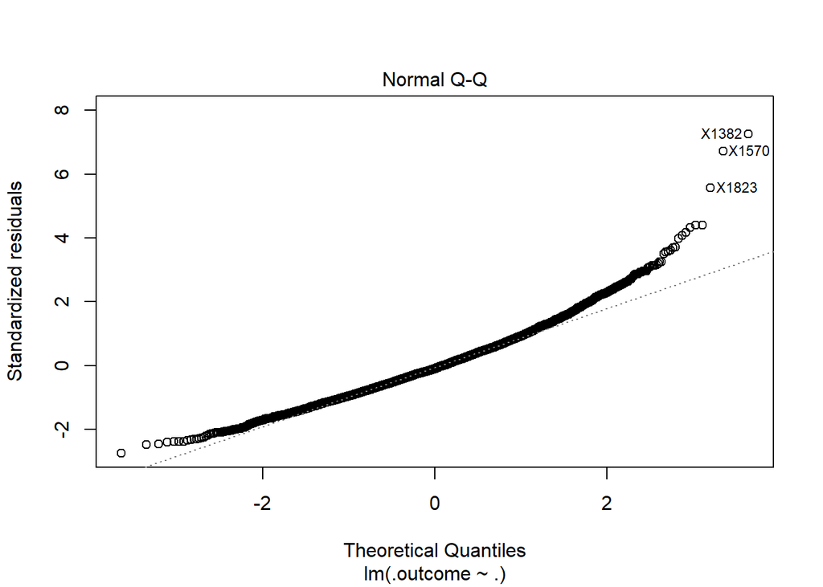

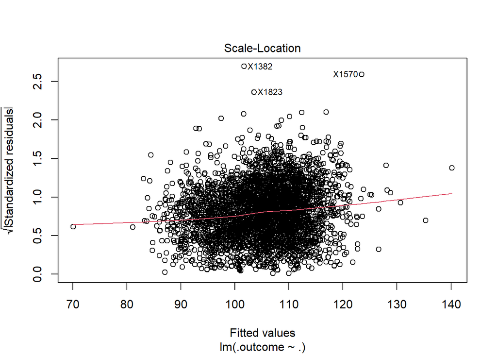

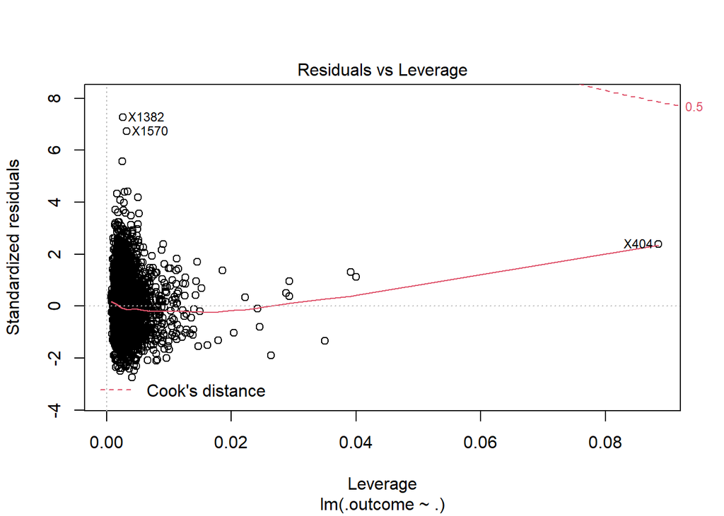

```r
Chol_ols_tune_num <- train(x = Chol_num_tr_X, y = Chol_train_y, method = "lm", trControl = Chol_control_num)
plot(Chol_ols_tune_num$finalModel)
```

```r
summary(Chol_ols_tune_num$finalModel)
```

```
##
## Call:
## lm(formula = .outcome ~ ., data = dat)
##
## Residuals:
##     Min      1Q  Median      3Q     Max
## -95.467 -23.705  -3.484  19.616 252.285
##
## Coefficients: (1 not defined because of singularities)
##                 Estimate Std. Error t value Pr(>|t|)
## (Intercept)     105.2332     0.5724 183.830  < 2e-16 ***
## RIDAGEYR          4.7111     0.7542   6.247 4.67e-10 ***
## INDFMPIR          1.2124     0.6242   1.942 0.052179 .
## BMXWT            -3.0812     5.6647  -0.544 0.586519
## BMXHT             0.6167     2.7006   0.228 0.819391
## BMXBMI           -2.1456     5.7513  -0.373 0.709124
## BMXLEG            1.9531     1.0102   1.933 0.053275 .
## BMXARML          -2.3916     1.0924  -2.189 0.028638 *
## BMXARMC          11.0858     1.5514   7.146 1.08e-12 ***
## BMXWAIST          4.0671     1.9632   2.072 0.038369 *
## BMXHIP           -6.6430     2.2078  -3.009 0.002639 **
## RIAGENDR_Male    -3.3691     0.9501  -3.546 0.000396 ***
## RIAGENDR_Female       NA         NA      NA       NA
## ---
## Signif. codes:  0 '***' 0.001 '**' 0.01 '*' 0.05 '.' 0.1 ' ' 1
##
## Residual standard error: 34.76 on 3684 degrees of freedom
## Multiple R-squared:  0.04226,    Adjusted R-squared:  0.0394
## F-statistic: 14.78 on 11 and 3684 DF,  p-value: < 2.2e-16
```

### Final OLS Model

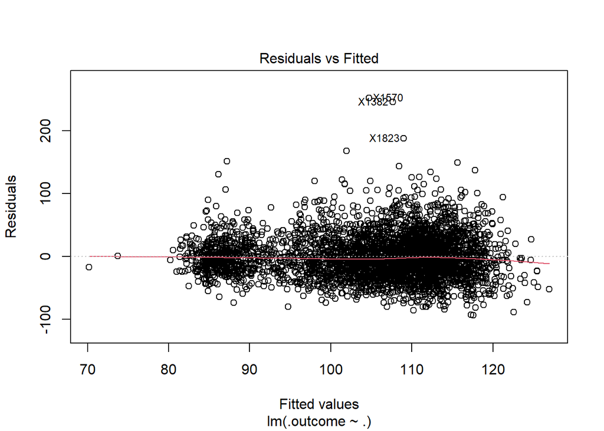

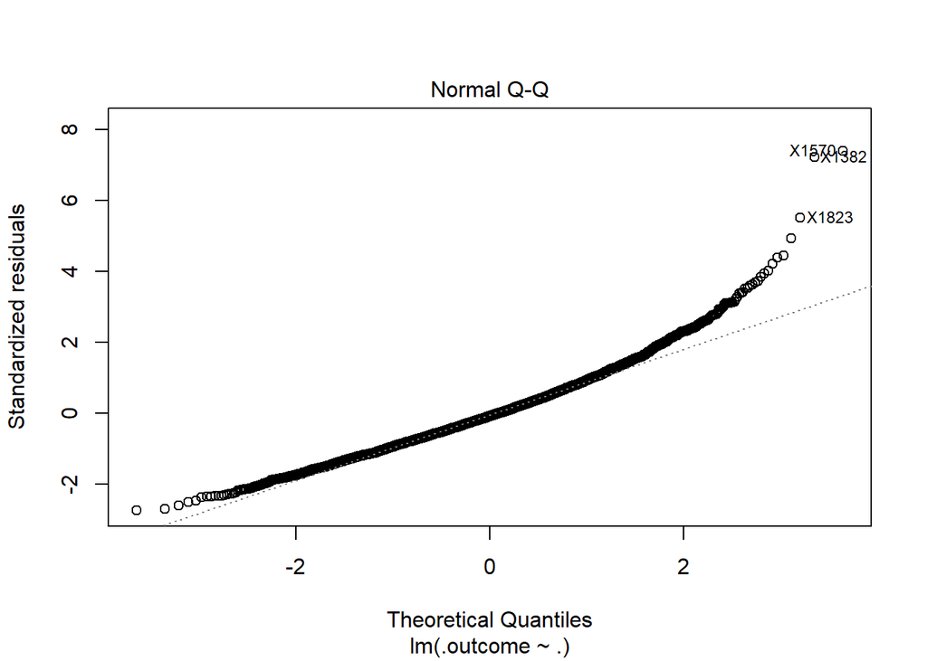

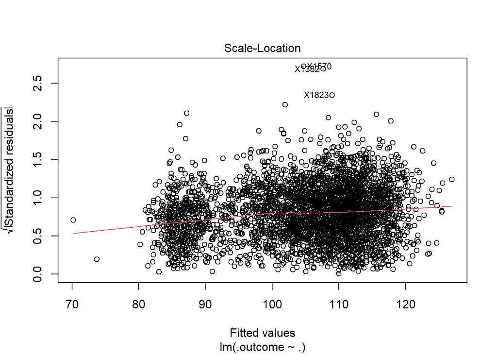

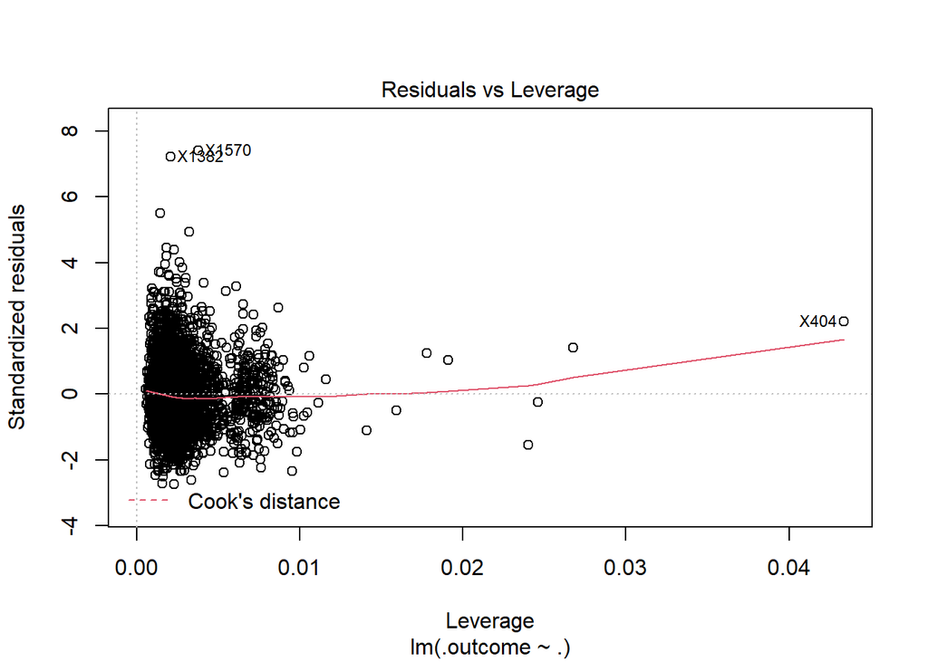

```r
Chol_sig_tr <- Chol_tr_X_imp_fin %>% select(RIDAGEYR, BMXHT, BMXBMI, BMXLEG, BMXARMC,  DMDBORN4_Oth, DMDEDUC2_NA, MIALANG_NA, AIALANGA_NA)
Chol_ols <- train(x = Chol_sig_tr, y = Chol_train_y, method = "lm", trControl = Chol_control)
plot(Chol_ols$finalModel)
```

```r
summary(Chol_ols$finalModel)
```

```
##
## Call:
## lm(formula = .outcome ~ ., data = dat)
##
## Residuals:
##     Min      1Q  Median      3Q     Max
## -93.570 -23.022  -2.777  19.504 252.299
##
## Coefficients:
##              Estimate Std. Error t value Pr(>|t|)
## (Intercept)  105.2477     0.5615 187.436  < 2e-16 ***
## RIDAGEYR       4.8758     0.9228   5.284 1.34e-07 ***
## BMXHT         -3.6994     0.9837  -3.761 0.000172 ***
## BMXBMI        -4.3529     1.4249  -3.055 0.002268 **
## BMXLEG         2.3397     0.9676   2.418 0.015656 *
## BMXARMC        5.8276     1.4811   3.935 8.49e-05 ***
## DMDBORN4_Oth   2.3726     0.6055   3.918 9.07e-05 ***
## DMDEDUC2_NA   -5.1963     0.7824  -6.641 3.57e-11 ***
## MIALANG_NA     2.9351     0.6732   4.360 1.34e-05 ***
## AIALANGA_NA   -6.3145     0.8050  -7.844 5.65e-15 ***
## ---
## Signif. codes:  0 '***' 0.001 '**' 0.01 '*' 0.05 '.' 0.1 ' ' 1
##
## Residual standard error: 34.13 on 3686 degrees of freedom
## Multiple R-squared:  0.07647,    Adjusted R-squared:  0.07421
## F-statistic: 33.91 on 9 and 3686 DF,  p-value: < 2.2e-16
```

```r
#Predict on test data
Chol_ols_res <- predict(Chol_ols, Chol_test_X)
```

## PCR and PLS

### PCR

```r
set.seed(123)
Chol_pcr <- train(x = Chol_tr_X_imp_fin, y = Chol_train_y, method = "pcr", tuneGrid = expand.grid(ncomp=1:32), trControl = Chol_control)
Chol_pcr
```

```
## Principal Component Analysis
##
## 3696 samples
##   32 predictor
##
## No pre-processing
## Resampling: Cross-Validated (10 fold)
## Summary of sample sizes: 51, 50, 48, 50, 46, 46, ...
## Resampling results across tuning parameters:
##
##   ncomp  RMSE          Rsquared      MAE
##    1     3.607365e+01  0.0009472784  2.824159e+01
##    2     3.582222e+01  0.0056720037  2.796978e+01
##    3     3.605529e+01  0.0065705319  2.821513e+01
##    4     3.595069e+01  0.0093855966  2.810244e+01
```

[output cut: 31 more lines]

```r
set.seed(123)
Chol_pcr_box <- train(x = Chol_tr_boxcox, y = Chol_train_y, method = "pcr", tuneGrid = expand.grid(ncomp=1:32), trControl = Chol_control)
Chol_pcr_box
```

```
## Principal Component Analysis
##
## 3696 samples
##   32 predictor
##
## No pre-processing
## Resampling: Cross-Validated (10 fold)
## Summary of sample sizes: 51, 50, 48, 50, 46, 46, ...
## Resampling results across tuning parameters:
##
##   ncomp  RMSE          Rsquared      MAE
##    1     3.607365e+01  0.0009472784  2.824159e+01
##    2     3.582222e+01  0.0056720037  2.796978e+01
##    3     3.605529e+01  0.0065705319  2.821513e+01
##    4     3.595069e+01  0.0093855966  2.810244e+01
```

[output cut: 31 more lines]

```r
set.seed(123)
Chol_pcr_num <- train(x = Chol_num_tr_X, y = Chol_train_y, method = "pcr", tuneGrid = expand.grid(ncomp=1:8), trControl = Chol_control_num)
Chol_pcr_num
```

```
## Principal Component Analysis
##
## 3696 samples
##   12 predictor
##
## No pre-processing
## Resampling: Cross-Validated (10 fold)
## Summary of sample sizes: 11, 9, 11, 10, 10, 11, ...
## Resampling results across tuning parameters:
##
##   ncomp  RMSE      Rsquared     MAE
##   1      40.19584  0.002466163  32.06866
##   2      40.48634  0.016438265  31.67889
##   3      40.25297  0.017418707  31.46126
##   4      41.03485  0.016028277  32.22306
##   5      43.03356  0.012647497  33.83330
##   6      47.53816  0.008249975  37.24345
##   7      59.70175  0.003126153  47.00137
##   8      67.61538  0.001586872  53.25255
##
## RMSE was used to select the optimal model using the smallest value.
## The final value used for the model was ncomp = 1.
```

```r
pcr_resamp <- Chol_pcr$results
pcr_resamp$Model <- "PCR"

box_pcr_resamp <- Chol_pcr_box$results
box_pcr_resamp$Model <- "BPCR"

num_pcr_resamp <- Chol_pcr_num$results
num_pcr_resamp$Model <- "PCR"
```

### PLS

```r
set.seed(123)
Chol_pls <- train(x = Chol_tr_X_imp_fin, y = Chol_train_y, method = "pls", tuneGrid = expand.grid(ncomp = 1:32), trControl = Chol_control)
Chol_pls
```

```
## Partial Least Squares
##
## 3696 samples
##   32 predictor
##
## No pre-processing
## Resampling: Cross-Validated (10 fold)
## Summary of sample sizes: 51, 50, 48, 50, 46, 46, ...
## Resampling results across tuning parameters:
##
##   ncomp  RMSE          Rsquared      MAE
##    1     3.619222e+01  0.0095702569  2.828385e+01
##    2     3.658160e+01  0.0141540807  2.861634e+01
##    3     3.789116e+01  0.0076494661  2.962868e+01
##    4     3.930606e+01  0.0065656458  3.066259e+01
```

[output cut: 31 more lines]

```r
set.seed(123)
Chol_pls_box <- train(x = Chol_tr_boxcox, y = Chol_train_y, method = "pls", tuneGrid = expand.grid(ncomp = 1:32), trControl = Chol_control)
Chol_pls_box
```

```
## Partial Least Squares
##
## 3696 samples
##   32 predictor
##
## No pre-processing
## Resampling: Cross-Validated (10 fold)
## Summary of sample sizes: 51, 50, 48, 50, 46, 46, ...
## Resampling results across tuning parameters:
##
##   ncomp  RMSE          Rsquared      MAE
##    1     3.619222e+01  0.0095702569  2.828385e+01
##    2     3.658160e+01  0.0141540807  2.861634e+01
##    3     3.789116e+01  0.0076494661  2.962868e+01
##    4     3.930606e+01  0.0065656458  3.066259e+01
```

[output cut: 31 more lines]

```r
set.seed(123)
Chol_pls_num <- train(x = Chol_num_tr_X, y = Chol_train_y, method = "pls", tuneGrid = expand.grid(ncomp = 1:8), trControl = Chol_control_num)
Chol_pls_num
```

```
## Partial Least Squares
##
## 3696 samples
##   12 predictor
##
## No pre-processing
## Resampling: Cross-Validated (10 fold)
## Summary of sample sizes: 11, 9, 11, 10, 10, 11, ...
## Resampling results across tuning parameters:
##
##   ncomp  RMSE      Rsquared     MAE
##   1      40.88057  0.010748084  32.26603
##   2      40.43823  0.018846454  31.51245
##   3      44.01601  0.009087219  34.61430
##   4      49.17924  0.006309826  38.63731
##   5      55.84753  0.003800729  43.81716
##   6      59.73218  0.001891028  46.82793
##   7      68.64725  0.002096613  54.11983
##   8      72.44313  0.002107833  57.07935
##
## RMSE was used to select the optimal model using the smallest value.
## The final value used for the model was ncomp = 2.
```

```r
pls_resamp <- Chol_pls$results
pls_resamp$Model <- "PLS"

pls_box_resamp <- Chol_pls_box$results
pls_box_resamp$Model <- "BPLS"

pls_num_resamp <- Chol_pls_num$results
pls_num_resamp$Model <- "PLS"
```

### Compare

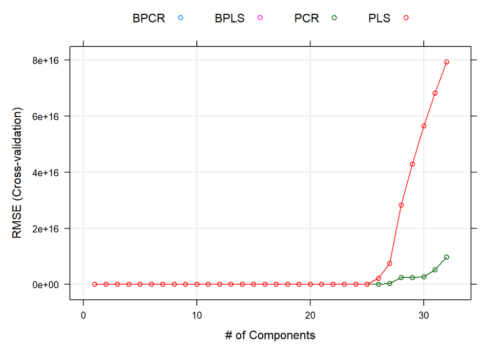

```r
plot_data <- rbind(pcr_resamp, box_pcr_resamp, pls_resamp, pls_box_resamp)
xyplot(RMSE ~ ncomp, data = plot_data, xlab = "# of Components", ylab = "RMSE (Cross-validation)", auto.key = list(columns = 4), groups = Model, type = c("o", "g"))
```

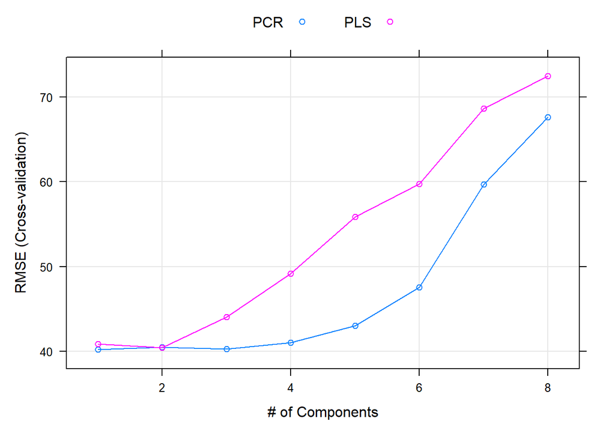

```r
plot2_data <- rbind(num_pcr_resamp, pls_num_resamp)
xyplot(RMSE ~ ncomp, data = plot2_data, xlab = "# of Components", ylab = "RMSE (Cross-validation)", auto.key = list(columns = 2), groups = Model, type = c("o", "g"))
```